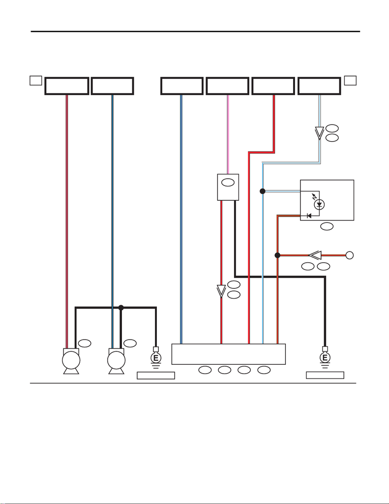

WI-374

Security System

WIRING SYSTEM

49.Security System

A: WIRING DIAGRAM

1. WITHOUT PUSH BUTTON START

WI-44564

15

1

3

1

3

4

5

2

1a 1a

i229

B551

i171

B:

B281

C: D:

B552

i230

i84

A:

B280

i10

2

1

i102

R167

A

W/L

L/R

R

W/L

BR/RD26

C6

D11 R

B7 L/R

W/L

RA24

P

4B

5RR

3P

BR/R BR/R

BR/R 1

W/L 40

REF. TO GND [a]

HORNHORN

REF. TO GND [f]

F47F5

SECURITY/

IMMOBILIZER

COMBINATION METER

BODY INTEGRATED UNIT

MB-21

HORN RELAY

FB-11

F/B FUSE NO. 15

(B)

FB-18

F/B FUSE NO. 7

(B)

MB-29

M/B FUSE NO. 8

(B)

MB-20

M/B FUSE NO. 9

: WITHOUT TPMS : KEYLESS ENTRY CM

WITH TPMS : TPMS & KEYLESS ENTRY CM

: WITHOUT TPMS : 3

WITH TPMS : 11

: WITHOUT TPMS : 7

WITH TPMS : 5

: WITHOUT TPMS : 4

WITH TPMS : 6

: WITHOUT TPMS : R80

WITH TPMS : R221

B1

B1

B

B

B/L2

R/L

B/L

R/L2

MB-19

M/B FUSE NO. 9

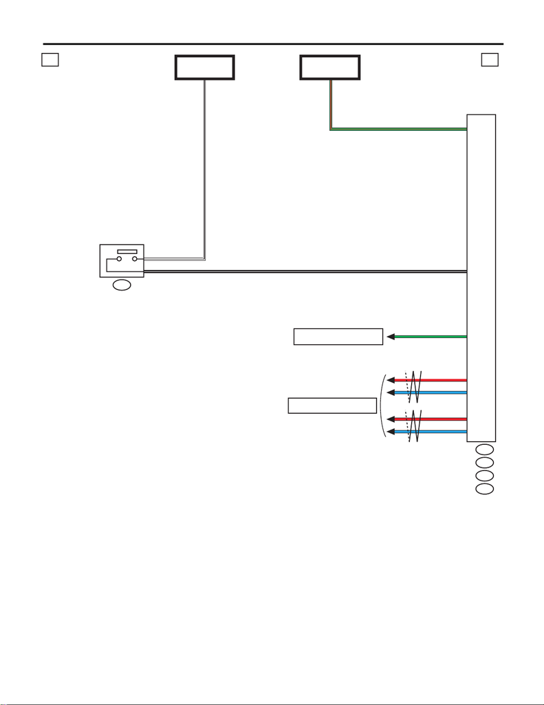

WI-375

Security System

WIRING SYSTEM

WI-44565

A:

B280

B: B281

i171

D:

C:

i84

1b 1b

L

R C27

C35

G D18

L

R B20

B28

B555

G/R

G/R B3

W/B

1

2

W/B

B/W A4B/W

BODY

INTEGRATED

UNIT

KEY WARNING

SWITCH

MB-28

M/B FUSE NO. 14

(B)

FB-38

F/B FUSE NO. 12

(IG)

REF. TO CAN COMMUNICATION

SYSTEM [b]

REF. TO TURN SIGNAL LIGHT &

HAZARD LIGHT SYSTEM [b]

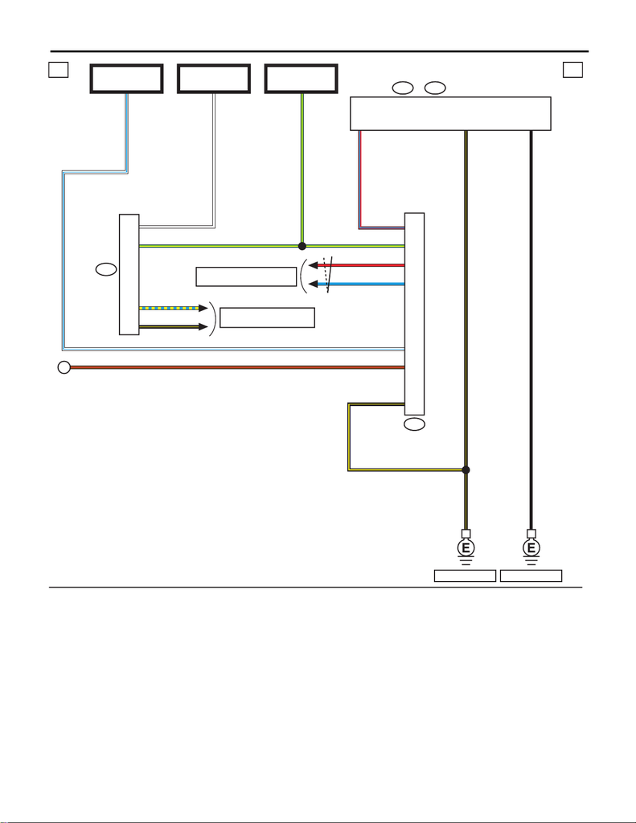

WI-376

Security System

WIRING SYSTEM

WI-44566

1

1c 1c

B40

B367

A:

B280

C:

i84

A

2

5R

6L

4W/L

8BR/R

7B/Y

1G/Y

R/L

4

5

G/Y

1

B/Y

W

8

16

BR/R

G/Y

W

W/L

A11R/L

A1B/Y

C1B

B/Y

B

BODY INTEGRATED UNIT

IMPACT

SENSOR

REF. TO ENGINE ELECTRICAL

SYSTEM [1g] [3f]

DATA LINK

CONNECTOR

FB-18

F/B FUSE NO. 7

(B)

MB-27

M/B FUSE NO. 13

(B)

FB-32

F/B FUSE NO. 4

(IG)

: ENGINE TYPE FA : B/R

ENGINE TYPE EJ : B/W

REF. TO CAN COMMUNICATION

SYSTEM [a]

REF. TO GND [e]REF. TO GND [c]

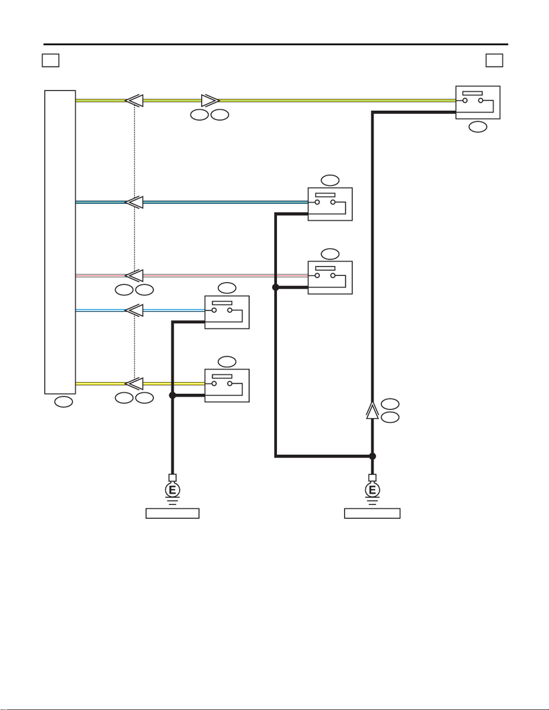

WI-377

Security System

WIRING SYSTEM

WI-44567

1d 1d

15

16

15

16

17

1

6

i84C:

R22

R9

i2 R339

R16

R12

i195 R382

R186

R24 R60

R24

R60

1

3

1

3

B

B

B

Y/W Y/W Y/W

L/W L/W L/W

C24

C14

B

B

1

3

1

3

W/R W/R

L/O L/O

C25

C13

C33

B

B

W/R

L/O

Y/L

B

3

2

Y/LY/L Y/L

B

TRUNK LID LOCK

SWITCH

FRONT DOOR

SWITCH RH

REAR DOOR

SWITCH RH

FRONT DOOR

SWITCH LH

BODY

INTEGRATED UNIT

REAR DOOR

SWITCH LH

REF. TO GND [h] REF. TO GND [f]

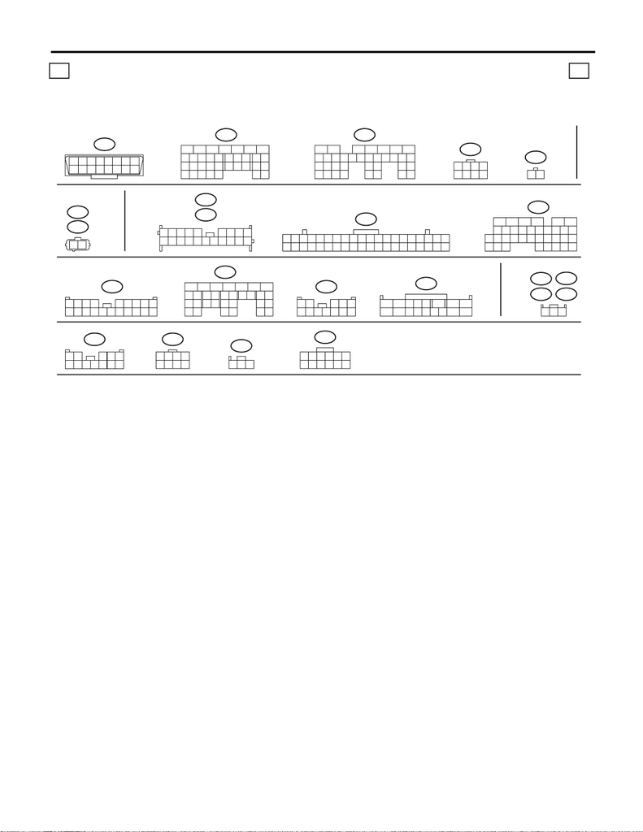

WI-378

Security System

WIRING SYSTEM

i195

i2

12345 6789

10 11 12 13 14 15 16 17 18 19 20

WI-44568

1e 1e

B40

(B)

1

9

8

16

2

10

7

15

3

11

6

14

4

12

5

13

B280

18

2719 20 21 22

23

26

24

25

28 29 3332 3430 31

98

15

1413121110

17

16

1234567

A:

B281B:

5672134

29

10 11 12 13 14 15

2524

16

30

98

17 18 19

20

28

21 22 23

3231

26 27

33 34 35

B367

1234

5678

B555

12

(B)

F47

(B)

F5

12

i10

11 12

9

10

7856341

2

15 1613 14 19

18

20

21 22 23 24 26

25

27 28 29 30 31 32 33 34 35 36 37 38 39 40

17

i84C:

19

18

21

20

2322 24 25 26

17

1

23

4

56

27

28 29 30

31 32 33 34 35

798

151413121110 16

89

19 20

1234 567

10 11 12 13 14 15 16 17 18

i102

i171D:

19

18

20 21

22

23

26

24

25

27

28 29

30 31

98

15

1413121110

17

16

1234567

123

R22R12

R9

R16

i230

(GR)

10

13

345 6

14 15 16 17

1211

12 78

9

R80

1234

5678

R221

11 12

9

10

78

65341

2

i229

12 345

6789

10 11 12

R60

12 345

6789

10 11 12

R186

123

LIST OF CONNECTORS

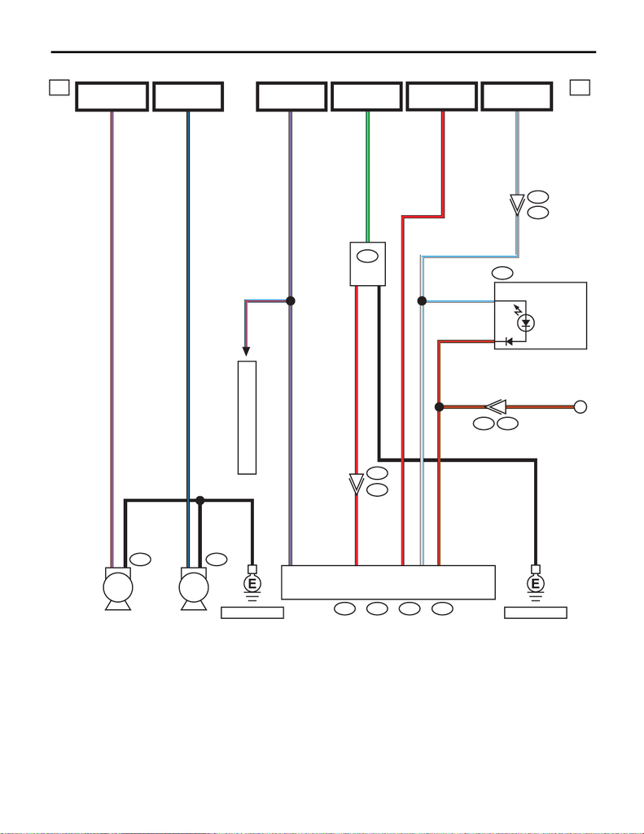

WI-379

Security System

WIRING SYSTEM

2. WITH PUSH BUTTON START

WI-44569

3

15

i230 B552

2a 2a

i10

i229

B551

W/L

W/L

R/L

B/L

L/R

R

W/L

BR/RD26

C6

W/L

RA24

BR/R 1

W/L 40

i171

B:

B281

C: D:

i84

A:

B280

B7 L/R

A

BR/R BR/R

L/R

i102

R167

F47F5

1

R211

D11 R

G/Y

5B

11RR

4 G/Y

B1

B1

B

B/L2

R/L2

B

REF. TO REMOTE ENGINE START

SYSTEM [1b] [2b]

BODY INTEGRATED UNIT

MB-29

M/B FUSE NO. 8

(B)

SECURITY/

IMMOBILIZER

COMBINATION METER

MB-21

HORN RELAY

FB-18

F/B FUSE NO. 7

(B)

MB-20

M/B FUSE NO. 9

MB-19

M/B FUSE NO. 9

TPMS CM

REF. TO GND [a]

HORNHORN

REF. TO GND [f]

FB-31

F/B FUSE NO. 4

(IG)

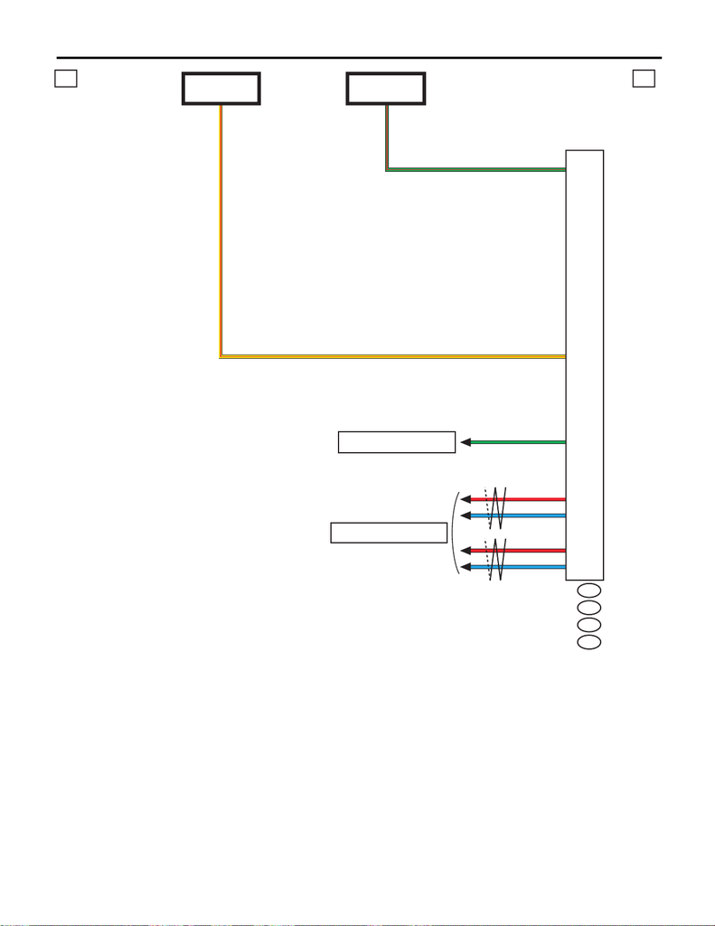

WI-380

Security System

WIRING SYSTEM

WI-44570

A:

B280

B: B281

i171

D:

C:

i84

2b 2b

L

R C27

C35

G D18

L

R B20

B28

G/R

G/R B3

Y/R

A4Y/R

BODY

INTEGRATED UNIT

FB-29

F/B FUSE NO. 31

(ACC)

FB-38

F/B FUSE NO. 12

(IG)

REF. TO CAN COMMUNICATION

SYSTEM [b]

REF. TO TURN SIGNAL LIGHT &

HAZARD LIGHT SYSTEM [b]

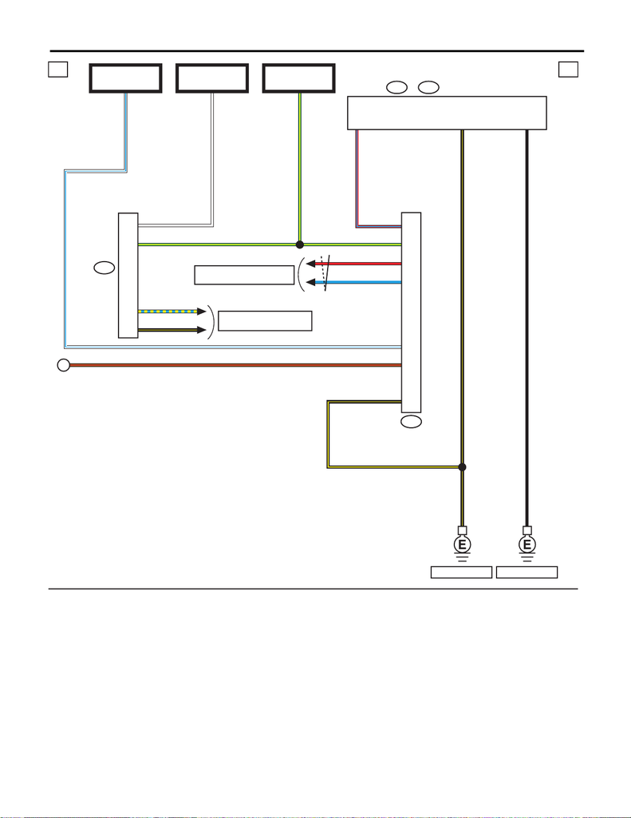

WI-381

Security System

WIRING SYSTEM

WI-44571

2c 2c

B40

B367

A:

B280

C:

i84

A

2

5R

6L

4W/L

8BR/R

7B/Y

1G/Y

R/L

4

5

G/Y

1

B/Y

W

8

16

BR/R

G/Y

W

W/L

A11R/L

A1B/Y

C1B

B/Y

B

BODY INTEGRATED UNIT

IMPACT

SENSOR

REF. TO ENGINE ELECTRICAL

SYSTEM [2g] [4f]

DATA LINK

CONNECTOR

FB-18

F/B FUSE NO. 7

(B)

MB-27

M/B FUSE NO. 13

(B)

FB-32

F/B FUSE NO. 4

(IG)

REF. TO CAN COMMUNICATION

SYSTEM [a]

REF. TO GND [e]REF. TO GND [c]

1

: ENGINE TYPE FA : B/R

ENGINE TYPE EJ : B/W

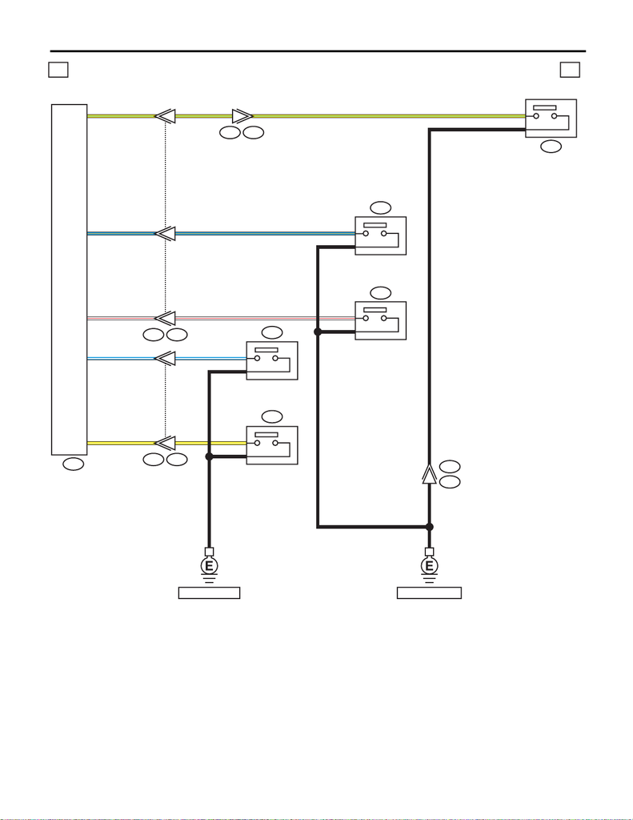

WI-382

Security System

WIRING SYSTEM

WI-44572

2d 2d

15

16

15

16

17

1

6

i84C:

R22

R9

i2 R339

R16

R12

i195 R382

R186

R24 R60

R24

R60

1

3

1

3

B

B

B

Y/W Y/W Y/W

L/W L/W L/W

C24

C14

B

B

1

3

1

3

W/R W/R

L/O L/O

C25

C13

C33

B

B

W/R

L/O

Y/L

B

3

2

Y/LY/L Y/L

B

TRUNK LID LOCK

SWITCH

FRONT DOOR

SWITCH RH

REAR DOOR

SWITCH RH

FRONT DOOR

SWITCH LH

BODY

INTEGRATED UNIT

REAR DOOR

SWITCH LH

REF. TO GND [h] REF. TO GND [f]

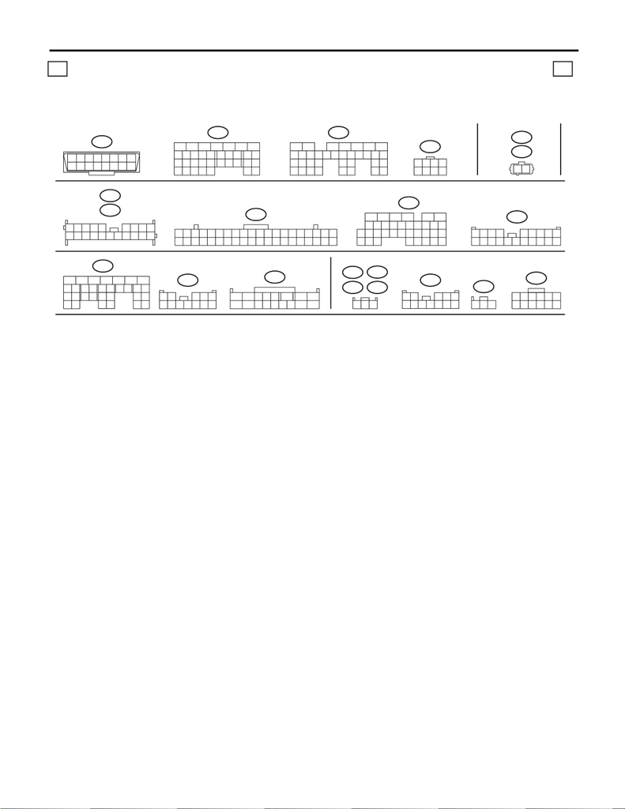

WI-383

Security System

WIRING SYSTEM

i2

12345 6789

10 11 12 13 14 15 16 17 18 19 20

WI-44573

2e 2e

B40

(B)

1

9

8

16

2

10

7

15

3

11

6

14

4

12

5

13

B280

18

2719 20 21 22

23

26

24

25

28 29 3332 3430 31

98

15

1413121110

17

16

1234567

A:

B281B:

5672134

29

10 11 12 13 14 15

2524

16

30

98

17 18 19

20

28

21 22 23

3231

26 27

33 34 35

B367

1234

5678

(B)

F47

(B)

F5

12

i10

11 12

9

10

7856341

2

15 1613 14 19

18

20

21 22 23 24 26

25

27 28 29 30 31 32 33 34 35 36 37 38 39 40

17

i84C:

19

18

21

20

2322 24 25 26

17

1

23

4

56

27

28 29 30

31 32 33 34 35

798

151413121110 16

89

19 20

1234 567

10 11 12 13 14 15 16 17 18

i102

i171D:

19

18

20 21

22

23

26

24

25

27

28 29

30 31

98

15

1413121110

17

16

1234567

i195

123

R22R12

R9

R16

i230

(GR)

10

13

345 6

14 15 16 17

1211

12 78

9

R211

11 12

9

10

78

65341

2

i229

12 345

6789

10 11 12

R60

12 345

6789

10 11 12

R186

123

LIST OF CONNECTORS